# Crime in the Time of Covid

Peter Sullivan

11/3/2021

# Introduction

In this hectic time of Covid 19 the world is changing, and its changing quickly. So quickly in fact that we barely have enough data to understand how these pandemic is really affecting our society. In this paper I will take a closer look into the effect of the covid Pandemic on Crime rates in the United States. I’ve obtained Crime Statistics from the Federal Bureau of Investigation (FBI), and Covid Statistics from CDC.

Utilizing the FBI’s and the CDC’s publicly available data, I’m proposing that Crime rates in the are United States are inversely related to the current covid 19 Hype in the United States. In other words, the stronger the covid 19 hype in a particular state, the lower the expected crimes.

# Method

## Gather, Clean and Prep

The first Step is to read in the Data. I obtained the Arrests by State records for the United States for 2020 and 2019. After I read in the data, the next step is to clean the data in order to prepare for the analysis

When pulling in the data, I noticed multiple issues. For example the column that included the State name was not showing the correct state for each row. The State names showed numbers when they should only have the name. The crime descriptor columns were written in ways that didn’t make sense. To fix these issues I used the following code below. Since the 2019 and 2020 csv sheets are in the same format, once I fixed one sheet, I just needed to repeat the same steps for the 2019 code.

```r
# 2020 Cleaning
USA_2020_crimes <- crime_2020 %>% fill(State)
USA_2020_crimes<-  USA_2020_crimes %>% mutate(States = removeNumbers(State))
Crime_data <- rename(USA_2020_crimes,  "Property Crimes" = "Property\ncrime2",
"Rape" = "Rape3",
"Aggravated Assault" = "Aggravated\nassault",
 "Drug and Abuse Violations" = "Drug \nabuse\nviolations",
"Violent Crimes" = "Violent\ncrime2", "Murder" = "Murder and\nnonnegligent\nmanslaughter" )
Crime_data$States[Crime_data$States == "FLORIDA, "]<- "FLORIDA"


#2019 Cleaning
USA_2019_crimes <- crime_2019 %>% fill(State)
USA_2019_crimes<-  USA_2019_crimes %>% mutate(States = removeNumbers(State))
Crime_data_2019 <- rename(USA_2019_crimes,  "Property Crimes" = "Property\ncrime2",
"Rape" = "Rape3",
"Aggravated Assault" = "Aggravated\nassault",
"Drug and Abuse Violations" = "Drug \nabuse\nviolations",
"Violent Crimes" = "Violent\ncrime2", "Murder" = "Murder and\nnonnegligent\nmanslaughter" )
Crime_data_2019$States[Crime_data_2019$States == "FLORIDA, " ] <- "FLORIDA"
```

## Initial Plots

Now that the data is cleaned, I can now take initial glimpses into the data I’ve collected. To perform this I used the package “usmap”. The way this package works is that you use the fips_info from the usmap package to tell the plot “usmap” function which states, citys and regions you plan to map. For this project, I am focusing on all States. So before I can plot my crime data, I first need to join the fips_info with my crime data. That way the plot us map function knows which state to correctly link what ever values I plan on plotting. For this project I decided to focus on only a few crimes, Property crimes, Aggravated Assault, and Murder.

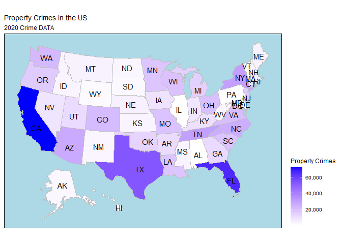

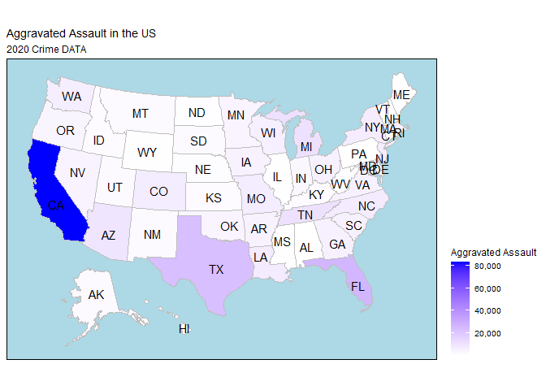

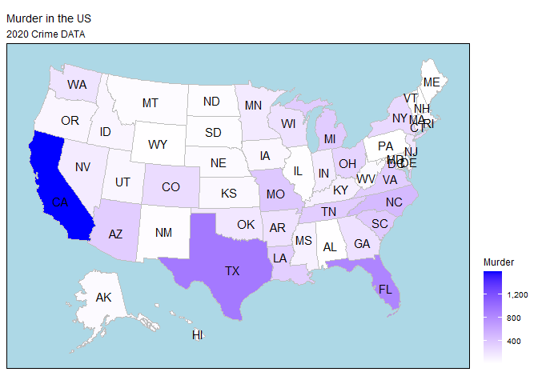

```r
library(usmap)
state_info <- fips_info()
state_info <- state_info %>% mutate("States" = toupper(full))
crimes <- c("Property Crimes", "Aggravated Assault","Murder")

# Plotting 2020 Crimes
for (crime in crimes){
  x <-  Crime_data %>% filter(X2 =="Total all ages") %>% select(States,crime) %>%
    distinct(States, .keep_all = TRUE)
  y <- full_join(x,state_info, by = "States")
  z <- plot_usmap(data = y, values = crime, labels = TRUE, color = "gray")+
scale_fill_continuous(low = "white", high = "blue", name = paste(crime),
label = scales::comma)+
    labs(title = paste(crime,"in the US"), subtitle = "2020 Crime DATA")+
    theme(panel.background = element_rect(color = "black", fill = "lightblue")) +
theme(legend.position = "right")
  print(z)
}
```

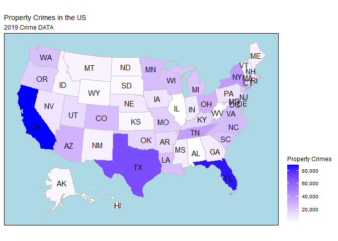

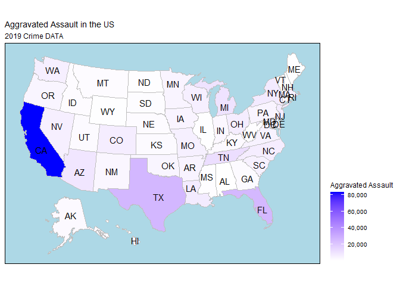

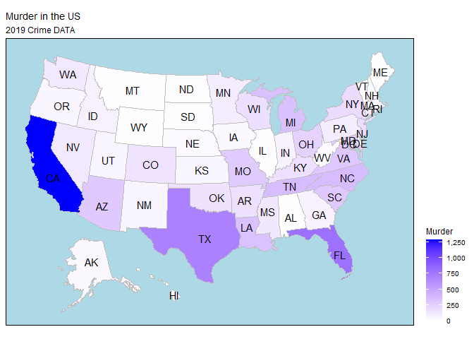

```r
# Plotting 2019
for (crime in crimes){
  x <-  Crime_data_2019 %>% filter(X2 =="Total all ages") %>% select(States,crime) %>% distinct(States, .keep_all = TRUE)
  y <- full_join(x,state_info, by = "States")
  z <- plot_usmap(data = y, values = crime, labels = TRUE, color = "gray")+ scale_fill_continuous(low = "white", high = "blue", name = paste(crime), label = scales::comma)+
    labs(title = paste(crime,"in the US"), subtitle = "2019 Crime DATA")+
    theme(panel.background = element_rect(color = "black", fill = "lightblue")) + theme(legend.position = "right")
  print(z)
}
```

### 2020 and 2019 Results

In all three figures for both 2020 and 2019, CA has the highest amount of crimes. There may be a lot of crime there, but this could also be due to the amount of population. Due to this issue, with out having the per-capita results, this data could be misleading. In order to really understand whats going on here I will need to dive deeper into the data.

## Futher Analysis

To truly understand what is happening, the total crimes themselves itself don’t matter. Instead I want to see the % change of crimes from 2019 to 2020. I will do this for all three crimes listed. Once I have the % change in crimes listed, then I can compare agains the covid data.

```r
Crime_data_2020_1 <- Crime_data %>% filter(X2 =="Total all ages") %>% select(States,`Property Crimes`,`Aggravated Assault`,Murder) %>% distinct(States, .keep_all = TRUE)

Crime_data_2019_1 <- Crime_data_2019 %>%  filter(X2 =="Total all ages") %>% select(States,`Property Crimes`,`Aggravated Assault`,Murder) %>% distinct(States, .keep_all = TRUE) %>% rename("Property crime 2019" = `Property Crimes`, "Aggravated Assault 2019"= `Aggravated Assault`, "Murder 2019" = Murder)

# Join DATA and Create Percent change columns

Crime_Change_data <- inner_join(Crime_data_2019_1,Crime_data_2020_1, by = "States")
Crime_Change_data <- Crime_Change_data %>% mutate(
  "Property Crime % Change" = (`Property Crimes` - `Property crime 2019`)/(`Property crime 2019`),
  "Aggravated Assualt % Change" = (`Aggravated Assault` - `Aggravated Assault 2019`)/ (`Aggravated Assault 2019`),
  "Murder % Change" = (Murder - `Murder 2019`)/`Murder 2019`
)
```

The code block above shows how I combined the 2020 and 2019 data and then created a calculated column for each crime.

## Plot Percent Change of Crime DATA

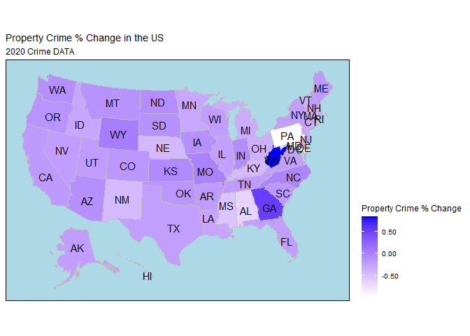

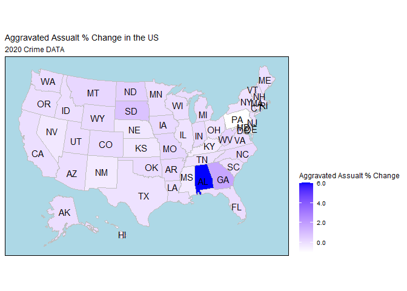

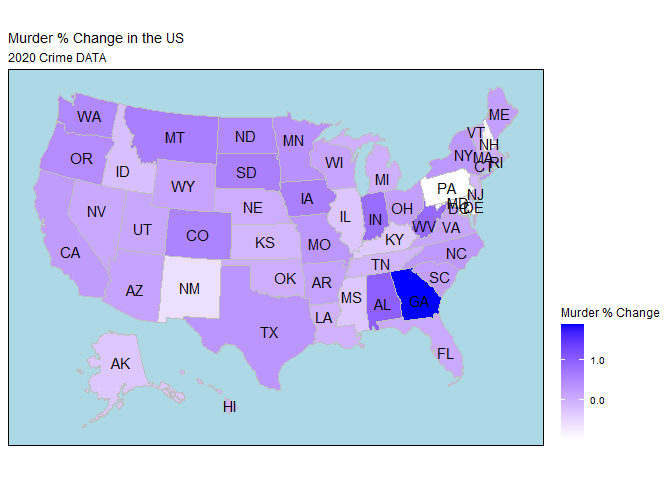

```r
crimes <- c("Property Crime % Change", "Aggravated Assualt % Change","Murder % Change")

# Plotting 2020 Crimes
for (crime in crimes){
  y <- full_join(Crime_Change_data,state_info, by = "States")
  z <- plot_usmap(data = y, values = crime, labels = TRUE, color = "gray")+ scale_fill_continuous(low = "white", high = "blue", name = paste(crime), label = scales::comma)+
    labs(title = paste(crime,"in the US"), subtitle = "2020 Crime DATA")+
    theme(panel.background = element_rect(color = "black", fill = "lightblue")) + theme(legend.position = "right")
  print(z)
}
```

## Results

These results are much better then the previous maps above. As we can see California and Texas are no longer in the top states for any of the crimes.

To truly understand these changes, I will also give a table of the top and bottom states for each crimes % change.

```r
library(knitr)

crimes <- c("Property Crime % Change", "Aggravated Assualt % Change","Murder % Change")

Crime_Change_data %>% arrange(`Property Crime % Change`) %>% select(States,`Property Crime % Change`) %>% slice(1:5) %>% kable(caption = "Largest Decrease in Property Crime")
```

Largest Decrease in Property Crime

| States | Property Crime % Change |
| --- | --- |
| PENNSYLVANIA | -0.9700970 |
| MARYLAND | -0.9150567 |
| ALABAMA | -0.6379310 |
| HAWAII | -0.5644000 |
| MISSISSIPPI | -0.5119228 |

```r
Crime_Change_data %>% arrange(desc(`Property Crime % Change`)) %>% select(States, `Property Crime % Change`) %>% slice(1:5) %>% kable(caption = "Largest Increase in Property Crime")
```

Largest Increase in Property Crime

| States | Property Crime % Change |
| --- | --- |
| WEST VIRGINIA | 0.8412447 |
| GEORGIA | 0.5394141 |
| WYOMING | 0.0521376 |
| MISSOURI | 0.0196389 |
| NORTH CAROLINA | -0.0105206 |

```r
Crime_Change_data %>% arrange(`Aggravated Assualt % Change`) %>% select(States,`Aggravated Assualt % Change`) %>% slice(1:5) %>% kable(caption = "Largest Decrease in Assault")
```

Largest Decrease in Assault

| States | Aggravated Assualt % Change |
| --- | --- |
| PENNSYLVANIA | -0.9767876 |
| MARYLAND | -0.9482368 |
| HAWAII | -0.4385965 |
| KENTUCKY | -0.3846154 |
| MISSISSIPPI | -0.3435028 |

```r
Crime_Change_data %>% arrange(desc(`Aggravated Assualt % Change`)) %>% select(States, `Aggravated Assualt % Change`) %>% slice(1:5) %>% kable(caption = "Largest Increase in Assault")
```

Largest Increase in Assault

| States | Aggravated Assualt % Change |
| --- | --- |
| ALABAMA | 6.0909091 |
| GEORGIA | 1.7259380 |
| SOUTH DAKOTA | 0.8287129 |
| NORTH DAKOTA | 0.4169381 |
| WEST VIRGINIA | 0.3105968 |

```r
Crime_Change_data %>% arrange(`Murder % Change`) %>% select(States,`Murder % Change`) %>% slice(1:5) %>% kable(caption = "Largest Decrease in Murder")
```

Largest Decrease in Murder

| States | Murder % Change |
| --- | --- |
| PENNSYLVANIA | -0.9714286 |
| MARYLAND | -0.9370079 |
| NEW HAMPSHIRE | -0.8666667 |
| NEW MEXICO | -0.5918367 |
| KENTUCKY | -0.3229814 |

```r
Crime_Change_data %>% arrange(desc(`Murder % Change`)) %>% select(States, `Murder % Change`) %>% slice(1:5) %>% kable(caption = "Largest Increase in Murder")
```

Largest Increase in Murder

| States | Murder % Change |
| --- | --- |
| DISTRICT OF COLUMBIA | Inf |
| GEORGIA | 1.8857143 |
| ALABAMA | 1.0000000 |
| WEST VIRGINIA | 0.8750000 |
| INDIANA | 0.8309859 |

## Results

# Method Continued

Now that I have a good idea of What states saw the largest increases and decreases in crime. I will now correlate that over to Covid Data provided by CDC.

## Covid DATA

When dealing with Covid, there are many different metrics that can be utilized. We could look at daily counts of infected, daily deaths, hospitalizations, or even total vaccinations. For this analysis I am only going to focus on the amount of deaths recorded in 2020 by state.

The plan is to compare the % change by the three crimes listed above by yearly total of deaths caused by Covid 19.

## Cleaning and Prepping DATA

```r
#str(covid_data)
covid_data$`End Date` <- as.Date(covid_data$`End Date`,"%m/%d/%Y")
#str(covid_data)
#covid_data
filtered_covid <- covid_data %>% filter(`End Date`< "2021-01-01") %>% filter(`Place of Death` == "Total - All Places of Death" & State != "United States" & Group == "By Year") %>% mutate("States" = toupper(State) ) %>% select(States, `COVID-19 Deaths`)
```

I First needed to clean and prep the data. I changed the dates column from a character type to a date type and filtered out the unnecessary information. I then plotted the deaths and normalized that data across all states using the plot “usmap” function.

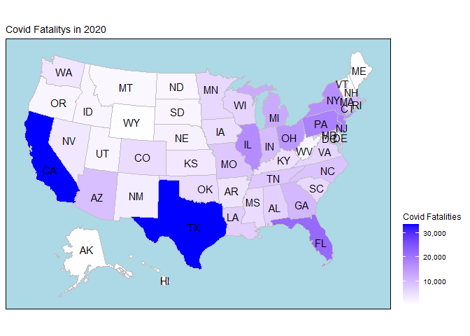

```r
 covid_mapdata <- full_join(filtered_covid,state_info, by = "States")
data_map <- covid_mapdata %>% select(fips, `COVID-19 Deaths`) %>% rename("Deaths" = `COVID-19 Deaths`)

data_map <- data.frame(data_map)


plot_usmap(data = data_map, values = "Deaths",labels = TRUE, color = "gray")+
  scale_fill_continuous(low = "white", high = "blue", name = "Covid Fatalities", label = scales::comma)+
    labs(title = "Covid Fatalitys in 2020")+
   theme(panel.background = element_rect(color = "black", fill = "lightblue")) + theme(legend.position = "right")
```

It looks like California and Texas had the largest amount of deaths around 30K. This info can be misleading, since states with lower populations will most likely have lower deaths but those deaths could be a higher percentage of the total population. To rectify this I will bring in the 2020 population data from the US Census for 2020, and I will create a field that is the amount of deaths per 100K population.

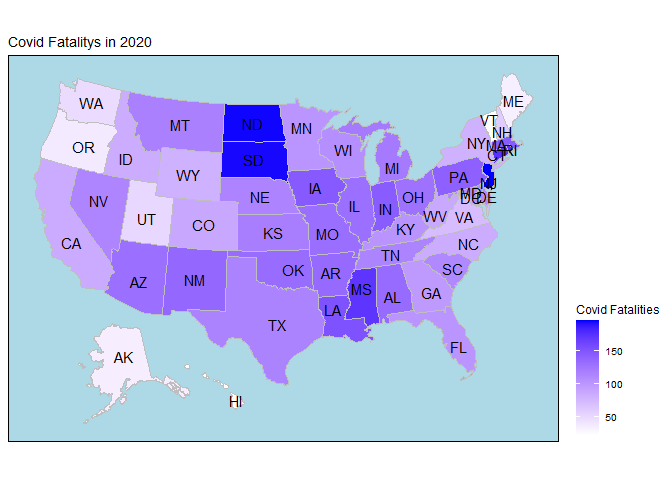

```r
population_2020 <- readxl::read_xlsx("2020 population.xlsx")



population_2020$State <- toupper(population_2020$State)
population_2020 <- rename(population_2020, "States" = State)

Covid_data_updated <- inner_join(covid_mapdata, population_2020, by ="States")
Covid_data_updated <- Covid_data_updated %>% mutate(
  Per_capita = (`COVID-19 Deaths`/`2020 Census`)*100000
)


plot_usmap(data = Covid_data_updated, values = "Per_capita",labels = TRUE, color = "gray")+
  scale_fill_continuous(low = "white", high = "blue", name = "Covid Fatalities", label = scales::comma)+
    labs(title = "Covid Fatalitys in 2020")+
   theme(panel.background = element_rect(color = "black", fill = "lightblue")) + theme(legend.position = "right")
```

# Results

```r
Top_covid <- Covid_data_updated %>% arrange(desc(Per_capita)) %>% select(States,Per_capita) %>% slice(1:5)

Low_covid <- Covid_data_updated %>% arrange((Per_capita)) %>% select(States,Per_capita) %>% slice(1:5)


Top_covid %>% kable(caption = "Highest Covid Fatalities by State")
```

Highest Covid Fatalities by State

| States | Per_capita |
| --- | --- |
| NEW JERSEY | 195.3172 |
| NORTH DAKOTA | 194.1999 |
| SOUTH DAKOTA | 193.4210 |
| RHODE ISLAND | 174.7801 |
| CONNECTICUT | 174.4619 |

```r
Low_covid %>% kable(caption = "Lowest Covid Fatalities by State")
```

Lowest Covid Fatalities by State

| States | Per_capita |
| --- | --- |
| VERMONT | 22.54784 |
| HAWAII | 25.08124 |
| MAINE | 34.13197 |
| ALASKA | 34.63364 |
| OREGON | 38.04349 |

```r
x1<- Crime_Change_data %>% arrange(`Property Crime % Change`) %>% select(States,`Property Crime % Change`) %>% slice(1:5)

y_1<-Crime_Change_data %>% arrange(desc(`Property Crime % Change`)) %>% select(States, `Property Crime % Change`) %>% slice(1:5)

x2<- Crime_Change_data %>% arrange(`Aggravated Assualt % Change`) %>% select(States,`Aggravated Assualt % Change`) %>% slice(1:5)
y2<- Crime_Change_data %>% arrange(desc(`Aggravated Assualt % Change`)) %>% select(States, `Aggravated Assualt % Change`) %>% slice(1:5)

x3<- Crime_Change_data %>% arrange(`Murder % Change`) %>% select(States,`Murder % Change`) %>% slice(1:5)
y3<- Crime_Change_data %>% arrange(desc(`Murder % Change`)) %>% select(States, `Murder % Change`) %>% slice(1:5)



cbind(Top_covid,x1,x2,x3)
```

```
##         States Per_capita       States Property Crime % Change       States
## 1   NEW JERSEY   195.3172 PENNSYLVANIA              -0.9700970 PENNSYLVANIA
## 2 NORTH DAKOTA   194.1999     MARYLAND              -0.9150567     MARYLAND
## 3 SOUTH DAKOTA   193.4210      ALABAMA              -0.6379310       HAWAII
## 4 RHODE ISLAND   174.7801       HAWAII              -0.5644000     KENTUCKY
## 5  CONNECTICUT   174.4619  MISSISSIPPI              -0.5119228  MISSISSIPPI
##   Aggravated Assualt % Change        States Murder % Change
## 1                  -0.9767876  PENNSYLVANIA      -0.9714286
## 2                  -0.9482368      MARYLAND      -0.9370079
## 3                  -0.4385965 NEW HAMPSHIRE      -0.8666667
## 4                  -0.3846154    NEW MEXICO      -0.5918367
## 5                  -0.3435028      KENTUCKY      -0.3229814
```

```r
cbind(Low_covid,y_1,y2,y3)
```

```
##    States Per_capita         States Property Crime % Change        States
## 1 VERMONT   22.54784  WEST VIRGINIA              0.84124473       ALABAMA
## 2  HAWAII   25.08124        GEORGIA              0.53941411       GEORGIA
## 3   MAINE   34.13197        WYOMING              0.05213764  SOUTH DAKOTA
## 4  ALASKA   34.63364       MISSOURI              0.01963886  NORTH DAKOTA
## 5  OREGON   38.04349 NORTH CAROLINA             -0.01052062 WEST VIRGINIA
##   Aggravated Assualt % Change               States Murder % Change
## 1                   6.0909091 DISTRICT OF COLUMBIA             Inf
## 2                   1.7259380              GEORGIA       1.8857143
## 3                   0.8287129              ALABAMA       1.0000000
## 4                   0.4169381        WEST VIRGINIA       0.8750000
## 5                   0.3105968              INDIANA       0.8309859
```

# Conclusion

I did not find a direct correlation with high amounts of covid deaths and decreases in crime. None of the top states with the highest amount of fatalities had the largest decreases in Crime, when compared to the other states.

If anything, it seems that covid fatalities may have actually increased the amount of crime performed. For example both North and South Dakota had very high amounts of covid fatalities and both states saw a large increase in aggravated assault when compared to other states.

# Limitations and Future Research

I found this project very interesting. Moving forward, I would like to look further into the data to help drive conclusions. I think incorporating more crime data from previous years would be necessary. Perhaps an increase of crime from 2019 to 2020 seems large when compared to the other states, but when compared to other years, it could be very small.

I would also need to dive deeper into the covid data. I think the age groups of deaths could also have an impact on the crime rates, if there is a correlation.

For this project, I only focused on the three crimes listed above. Perhaps other crimes had a higher correlation to covid then the crimes I chose. It might be interesting to perform linear regression analysis with the the current covid deaths per-capita that I have listed using the crimes themselves as covariates.